# Music store data analysis using SQL

Gordon Ma

2024-01-15

## Introduction

In this project, we use SQL comments to analyze the Chinook database, which is a public database containing the relevant information from a music store. The database can be accessed from the [website](https://github.com/lerocha/chinook-database). The following diagram displays the structure of this database.

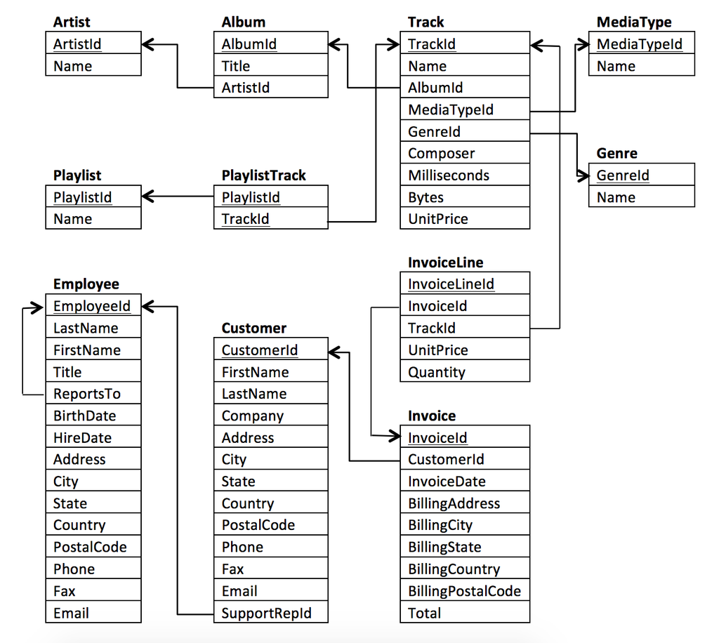

There are 11 tables in the Chinook sample database:

- `employees` table stores employee data such as employee ID, last name, first name, etc. It also has a field named `ReportsTo` to specify who reports to whom.
- `customers` table stores customer data.
- `invoices` & `invoice_items` tables: these two tables store invoice data. The `invoices` table stores invoice header data and the `invoice_items` table stores the invoice line items data.
- `artists'` table stores artists’ data. It is a simple table that contains only the artist’s ID and name.
- `aalbum`table stores data about a list of tracks. Each album belongs to one artist. However, one artist may have multiple albums.
- `media_types` table stores media types such as MPEG audio and AAC audio files.
- `genres` table stores music types such as rock, jazz, metal, etc.
- `tracks` table stores the data of songs. Each track belongs to one album.
- `playlists` & `playlist_track` tables: `playlists` table store data about playlists. Each playlist contains a list of tracks. Each track may belong to multiple playlists. The `playlist_track` table is used to reflect this relationship.

```r
#We first load the required packages in R
library(RSQLite)
```

```r
#Connect to your SQLite database file and list all the tables
db_conn <- dbConnect(SQLite(), dbname = "chinook.db")
dbListTables(db_conn)
```

```
##  [1] "albums"          "artists"         "customers"       "employees"
##  [5] "genres"          "invoice_items"   "invoices"        "media_types"
##  [9] "playlist_track"  "playlists"       "sqlite_sequence" "sqlite_stat1"
## [13] "tracks"
```

```r
#Query to read one of the table
query <- "SELECT * FROM playlists;"
result <- dbSendQuery(db_conn, query)
dbFetch(result)
```

```
##    PlaylistId                       Name
## 1           1                      Music
## 2           2                     Movies
## 3           3                   TV Shows
## 4           4                 Audiobooks
## 5           5                 90’s Music
## 6           6                 Audiobooks
## 7           7                     Movies
## 8           8                      Music
## 9           9               Music Videos
## 10         10                   TV Shows
## 11         11            Brazilian Music
## 12         12                  Classical
## 13         13  Classical 101 - Deep Cuts
## 14         14 Classical 101 - Next Steps
## 15         15 Classical 101 - The Basics
## 16         16                     Grunge
## 17         17        Heavy Metal Classic
## 18         18                On-The-Go 1
```

## As a music store manager, we would like to know which employees sold the most and made the highest profits.

```r
query <- "SELECT m.FirstName ||' '|| m.LastName AS ManagerName, E.FirstName ||' '|| E.LastName AS EmployeeName, E.Title, SUM(II.Quantity) AS total_sold, SUM(I.TOTAL) AS profits
  FROM employees AS E
  JOIN Customers AS C ON E.EmployeeId = C.SupportRepId
  JOIN invoices AS I ON I.CustomerId = C.CustomerId
  JOIN invoice_items AS II on I.InvoiceId = II.InvoiceId
  JOIN Employees m ON e.ReportsTo = m.EmployeeID
  GROUP BY E.EmployeeId
  ORDER BY profits DESC;
          "
result <- dbSendQuery(db_conn, query)
dbFetch(result)
```

```
##     ManagerName  EmployeeName               Title total_sold profits
## 1 Nancy Edwards  Jane Peacock Sales Support Agent        796 7427.06
## 2 Nancy Edwards Margaret Park Sales Support Agent        760 6931.40
## 3 Nancy Edwards Steve Johnson Sales Support Agent        684 6490.16
```

## How many users per country? And how much did users spend on each country?

```r
query <- "SELECT C.COUNTRY, COUNT(DISTINCT C.CUSTOMERID) AS total_user_count, SUM(I.total) AS total_profits
  FROM customers AS C
  JOIN invoices AS I
  GROUP BY 1
  ORDER BY 3 DESC;
          "
result <- dbSendQuery(db_conn, query)
(users <- dbFetch(result))
```

```
##           Country total_user_count total_profits
## 1             USA               13       30271.8
## 2          Canada                8       18628.8
## 3          France                5       11643.0
## 4          Brazil                5       11643.0
## 5         Germany                4        9314.4
## 6  United Kingdom                3        6985.8
## 7        Portugal                2        4657.2
## 8           India                2        4657.2
## 9  Czech Republic                2        4657.2
## 10         Sweden                1        2328.6
## 11          Spain                1        2328.6
## 12         Poland                1        2328.6
## 13         Norway                1        2328.6
## 14    Netherlands                1        2328.6
## 15          Italy                1        2328.6
## 16        Ireland                1        2328.6
## 17        Hungary                1        2328.6
## 18        Finland                1        2328.6
## 19        Denmark                1        2328.6
## 20          Chile                1        2328.6
## 21        Belgium                1        2328.6
## 22        Austria                1        2328.6
## 23      Australia                1        2328.6
## 24      Argentina                1        2328.6
```

## Returns the list of customers ordered by name, whose sales representatives are in Canada.

```r
query <- "SELECT customerid,
       firstname,
       lastname
  FROM customers
 WHERE supportrepid IN (
           SELECT employeeid
             FROM employees
            WHERE country = 'Canada'
            )
            ORDER BY firstname, lastname;
          "
result <- dbSendQuery(db_conn, query)
dbFetch(result)
```

```
##    CustomerId FirstName     LastName
## 1          32     Aaron     Mitchell
## 2          11 Alexandre        Rocha
## 3           7    Astrid       Gruber
## 4           4     Bjørn       Hansen
## 5          39   Camille      Bernard
## 6           8      Daan      Peeters
## 7          20       Dan       Miller
## 8          56     Diego    Gutiérrez
## 9          40 Dominique     Lefebvre
## 10         10   Eduardo      Martins
## 11         30    Edward      Francis
## 12         33     Ellie     Sullivan
## 13         52      Emma        Jones
## 14         50   Enrique        Muñoz
```

[output cut: 45 more lines]

## Which city has the best customers? We would like to throw a promotional Music Festival in the city that made the most money.

```r
query <- "SELECT BILLINGCITY AS City,
  SUM(TOTAL) AS profits
  FROM invoices
  GROUP BY 1
  ORDER BY 2 DESC;
          "
result <- dbSendQuery(db_conn, query)
(city_sales <- dbFetch(result))
```

```
##                   City profits
## 1               Prague   90.24
## 2                Paris   77.24
## 3        Mountain View   77.24
## 4            São Paulo   75.24
## 5               London   75.24
## 6               Berlin   75.24
## 7           Fort Worth   47.62
## 8             Santiago   46.62
## 9               Dublin   45.62
## 10            Budapest   45.62
## 11      Salt Lake City   43.62
## 12           Frankfurt   43.62
## 13             Chicago   43.62
## 14              Vienne   42.62
```

[output cut: 39 more lines]

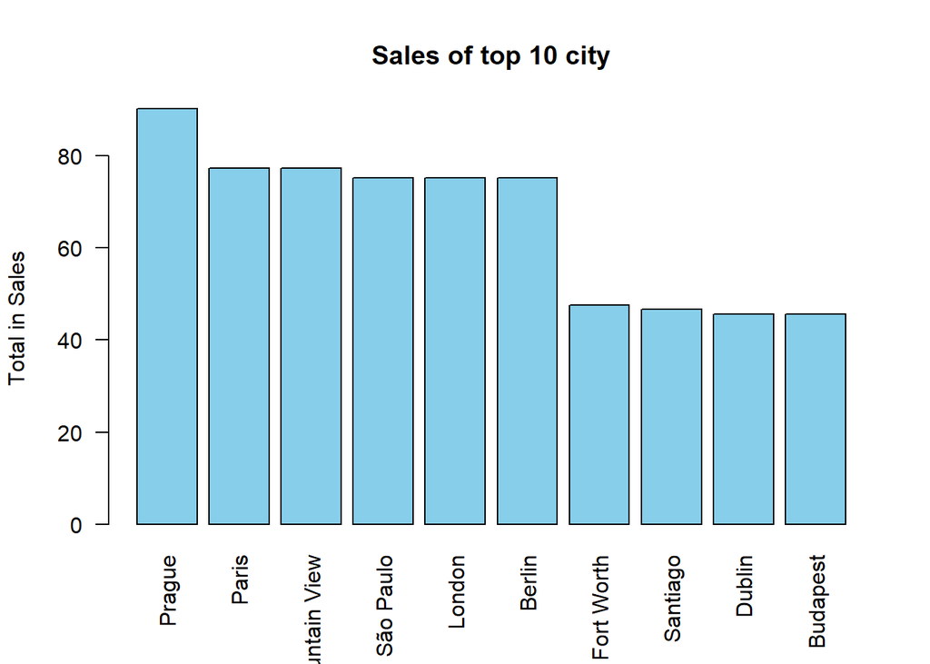

```r
#Visualization of each city's profits
barplot(city_sales$profits[1:10], names.arg = city_sales$City[1:10], col = "skyblue", main = "Sales of top 10 city", ylab = "Total in Sales", las = 2)
```

## We decide to host a Music Festival in Prague. We would like to find out what genres of music do people like.

```r
query <- "SELECT G.Name, SUM(TOTAL) as profits
  FROM invoices AS I
  JOIN invoice_items AS II ON I.InvoiceId = II.InvoiceId
  JOIN tracks AS T ON T.TrackId = II.TrackId
  JOIN genres AS G ON T.GenreId = G.GenreId
  WHERE I.billingCity = 'Prague'
  GROUP BY G.Name
  ORDER BY profits DESC;
          "
result <- dbSendQuery(db_conn, query)
(genres_profits <- dbFetch(result) )
```

```
##                  Name profits
## 1                Rock  226.02
## 2            TV Shows  188.88
## 3               Drama  146.16
## 4               Latin   81.27
## 5               Metal   69.36
## 6  Alternative & Punk   66.45
## 7     Science Fiction   25.86
## 8            R&B/Soul   17.82
## 9                Jazz   17.82
## 10  Electronica/Dance   17.82
## 11                Pop   15.84
## 12              Blues    5.94
```

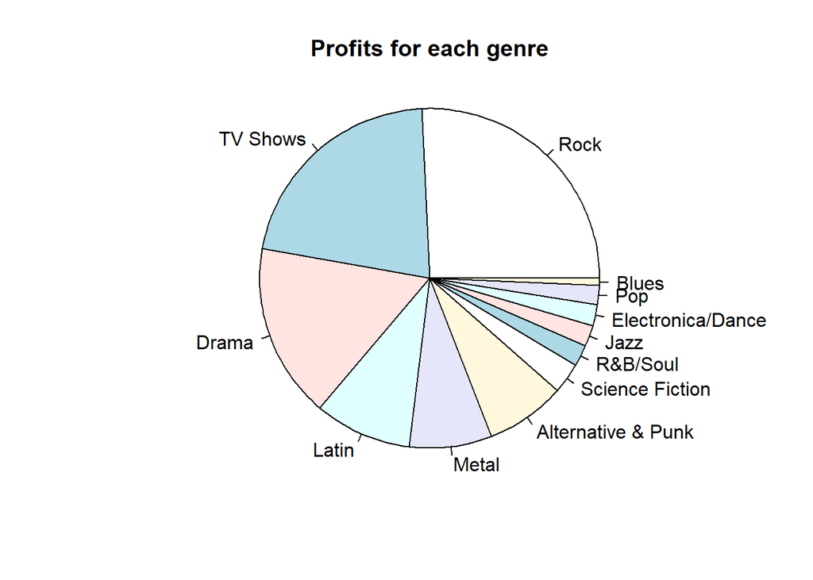

```r
#Create a pie chart to visualize the profits of each generes
pie(genres_profits$profits, genres_profits$Name, radius = 1.0, main = "Profits for each genre")
```

## So Rock music is the most popular in Prague. We would like to invite artists who is known for Rock music. Return a table of rock artists with at least 20 tracks of rock music, and ordered them by total profits made.

```r
query <- "SELECT AR.Name, COUNT(T.Name) AS Num_of_RockMusic, SUM(I.Total) AS Profits_made
  FROM tracks AS T
  JOIN genres AS G ON T.GENREID = G.GENREID
  JOIN albums AS AL ON AL.ALBUMID = T.ALBUMID
  JOIN artists AS AR ON AR.ARTISTID = AL.ARTISTID
  JOIN invoice_items AS II ON II.TrackId = T.TrackId
  JOIN invoices AS I ON I.InvoiceId = II.InvoiceId
  WHERE G.Name = 'Rock'
  GROUP BY AR.Name HAVING Num_of_RockMusic >= 20
  ORDER BY Profits_made DESC
           "
result <- dbSendQuery(db_conn, query)
dbFetch(result)
```

```
##                            Name Num_of_RockMusic Profits_made
## 1                            U2               91       773.65
## 2                  Led Zeppelin               87       620.73
## 3                   Deep Purple               44       550.44
## 4                   Iron Maiden               54       473.22
## 5                     Van Halen               29       336.82
## 6                     Pearl Jam               26       335.61
## 7                         Queen               37       256.41
## 8  Creedence Clearwater Revival               37       215.82
## 9                          Kiss               31       211.86
## 10                Guns N' Roses               26       142.56
```

## We will invite the band U2 since they had the highest number of rock music and made the most profits. Let us find out which are their biggest fan and also invite them.

```r
query <- "SELECT C.firstname, C.lastname,SUM(II.Quantity * II.UnitPrice) AS money_spend
  FROM customers AS C
  JOIN invoices AS I ON C.CustomerId = I.CustomerId
  JOIN invoice_items AS II ON I.InvoiceId = II.InvoiceId
  JOIN tracks AS T ON T.TrackId = II.TrackId
  JOIN albums AS AL ON AL.AlbumId = T.AlbumId
  JOIN artists AS AR ON AR.artistid = AL.artistid
  WHERE AR.Name = 'U2'
  GROUP BY C.customerId
  ORDER BY money_spend DESC
  LIMIT 10;
           "
result <- dbSendQuery(db_conn, query)
dbFetch(result)
```

```
##    FirstName    LastName money_spend
## 1     Astrid      Gruber        8.91
## 2   Madalena     Sampaio        8.91
## 3    Richard  Cunningham        7.92
## 4    Eduardo     Martins        5.94
## 5     Robert       Brown        5.94
## 6       Hugh    O'Reilly        5.94
## 7  Stanisław      Wójcik        5.94
## 8     Helena        Holý        4.95
## 9       Mark      Taylor        4.95
## 10 František Wichterlová        3.96
```

## Let us find out which album of U2 sold the most?

```r
query <- "SELECT AL.title, SUM(Quantity) as total_sold
          FROM albums AS AL
          JOIN tracks AS T ON T.AlbumId = AL.AlbumId
          JOIN invoice_items as II ON II.trackid = T.trackid
          WHERE artistid IN (
          SELECT artistid
          FROM artists
          WHERE name = 'U2'
          )
          GROUP BY al.title
          ORDER BY total_sold DESC
          "
result <- dbSendQuery(db_conn, query)
dbFetch(result)
```

```
##                                                               Title total_sold
## 1                                                    Rattle And Hum         17
## 2  Instant Karma: The Amnesty International Campaign to Save Darfur         16
## 3                                                               War         11
## 4                                             The Best Of 1980-1990         11
## 5                                                 B-Sides 1980-1990         11
## 6                                                               Pop         10
## 7                                   How To Dismantle An Atomic Bomb         10
## 8                                                           Zooropa          9
## 9                                   All That You Can't Leave Behind          6
## 10                                                     Achtung Baby          6
```

## To find out what are other songs do U2’s fans like to listen to, we want to find which playlist contain U2’s tracks?

```r
query <- "SELECT P.Name AS name_of_the_playlist, COUNT(DISTINCT T.Name) as total_U2_song
          FROM playlists as P
          JOIN playlist_track as PT ON P.PlaylistId = PT.PlaylistId
          JOIN tracks AS T ON T.trackid = PT.trackid
          WHERE AlbumId IN (
            SELECT AlbumId
            FROM artists AS AR
            JOIN albums AS AL ON AR.artistid = AL.artistid
            WHERE AR.name = 'U2'
          )
          GROUP BY P.PlaylistId
          ORDER BY total_U2_song DESC;
          "
result <- dbSendQuery(db_conn, query)
dbFetch(result)
```

```
##   name_of_the_playlist total_U2_song
## 1                Music           124
## 2                Music           124
## 3           90’s Music            62
```

```r
#Explore the 90's Music playlist
query <- "SELECT T.*
          FROM tracks AS T
          JOIN playlist_track as PT ON T.trackid = PT.trackid
          JOIN playlists as PL on PL.playlistid = PT.playlistid
          WHERE PL.name = '90’s Music'
          LIMIT 10;
          "
result <- dbSendQuery(db_conn, query)
dbFetch(result)
```

```
##    TrackId                     Name AlbumId MediaTypeId GenreId
## 1        3          Fast As a Shark       3           2       1
## 2        4        Restless and Wild       3           2       1
## 3        5     Princess of the Dawn       3           2       1
## 4       23            Walk On Water       5           1       1
## 5       24      Love In An Elevator       5           1       1
## 6       25                 Rag Doll       5           1       1
## 7       26            What It Takes       5           1       1
## 8       27 Dude (Looks Like A Lady)       5           1       1
## 9       28        Janie's Got A Gun       5           1       1
## 10      29                   Cryin'       5           1       1
##                                                                  Composer
## 1                     F. Baltes, S. Kaufman, U. Dirkscneider & W. Hoffman
## 2  F. Baltes, R.A. Smith-Diesel, S. Kaufman, U. Dirkscneider & W. Hoffman
## 3                                              Deaffy & R.A. Smith-Diesel
```

[output cut: 18 more lines]